# NNDSS Data Analysis

# NNDSS Data Analysis

Exploratory Analysis of the National Notifiable Diseases Surveillance System (NNDSS) public dataset – [influenza (laboratory confirmed)](https://www.health.gov.au/resources/publications/national-notifiable-diseases-surveillance-system-nndss-public-dataset-influenza-laboratory-confirmed?language=en)

**Publication date:** September 2022

## Setup

```r
library(jsonlite)
```

**6 Variables**

- Week `date, ending on the Friday`
- State `NSW, NT, Qld, SA, Tas, Vic, WA`
- Age `bucketed in 5 year groups`
- Sex `Male, Female, Unknown`
- Indigenous `Not available, Indigenous, Non-Indigenous, Unknown`
- Type `A(H1N1)pdm09, A(unsubtyped), A(H3N2), B, A and B, Untyped, C, A(H1N1)`

*Note: `A(H3N2)` are largely derived from PCR results reported as A(H3). Based on nationally available subtyping and characterisation data, these cases are assumed to be A(H3N2). `A and B` denotes a co-infection of both influenza A and influenza B viruses.*

## Caveats from source:

- These notification data represent only a proportion of the total cases occurring in the community, that is, only those cases for which health care was sought, a test conducted and a diagnosis made.
- In interpreting these data it is important to note that changes in notifications over time may not solely reflect changes in disease prevalence or incidence. Changes in testing policies; screening programs including the preferential testing of high-risk populations; the use of less invasive and more sensitive diagnostic tests; and periodic awareness campaigns, may influence the number of notifications that occur annually.
- No ACT data
- Social distancing measures due to COVID causes discontinuities

[See full disclosure](https://www.health.gov.au/sites/default/files/documents/2022/09/national-notifiable-diseases-surveillance-system-nndss-public-dataset-influenza-laboratory-confirmed-caveats.pdf)

## Basic EDA

```r
data %>% count(State)
```

| State | n |
| --- | --- |
| NSW | 370348 |
| NT | 11138 |
| Qld | 274022 |
| SA | 128974 |
| Tas | 14031 |
| Vic | 199907 |
| WA | 73128 |

```r
data %>% count(Age)
```

| Age | n |
| --- | --- |
| 00-04 | 117648 |
| 05-09 | 124677 |
| 10-14 | 76866 |
| 15-19 | 63288 |
| 20-24 | 55724 |
| 25-29 | 59259 |
| 30-34 | 66810 |
| 35-39 | 66791 |
| 40-44 | 58468 |
| 45-49 | 53879 |

[output cut: 9 more lines]

```r
data %>% count(Sex)
```

| Sex | n |
| --- | --- |
| Female | 574812 |
| Male | 493221 |
| Unknown | 3515 |

```r
data %>% count(Type)
```

| Type | n |
| --- | --- |
| A and B | 2017 |
| A(H1N1) | 6674 |
| A(H1N1)pdm09 | 76151 |
| A(H3N2) | 59806 |
| A(unsubtyped) | 632961 |
| B | 293072 |
| C | 37 |
| Untyped | 830 |

```r
NA
```

*Thoughts*

- May want to normalise each state by the population at the time if doing statewise comparisons
- May want to cut off after 2020, due to covid-era capture issues
- Clear seasonality (ETS?)

```
Plot variable not specified, automatically selected `.vars = Cases`
```

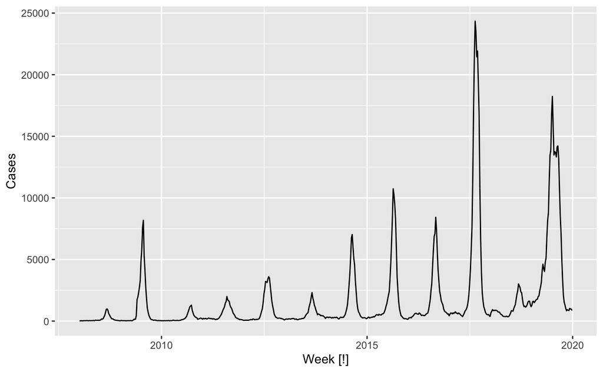

```r
# accumulate for a tsibble

data %>%
  filter(Week < as.Date("2020-01-01 UTC")) %>%
  select(Week:Sex) %>%
  group_by(Week,State,Age,Sex) %>%
  summarise(Cases = n()) %>% ungroup() %>%
  as_tsibble(index = Week, key = c(State, Age, Sex), regular = FALSE) -> datats
datats %>% summarise(Cases = sum(Cases)) %>% autoplot()
```

Decompose by year to show seasonality:

```
Plot variable not specified, automatically selected `y = Cases`
```

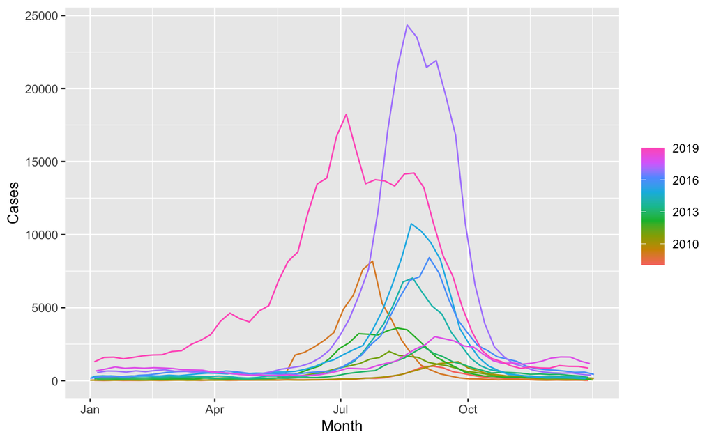

```r
datats %>%
  summarise(Cases = sum(Cases)) %>%
  gg_season() + labs(x = "Month")
```

```
Plot variable not specified, automatically selected `y = Cases`
```

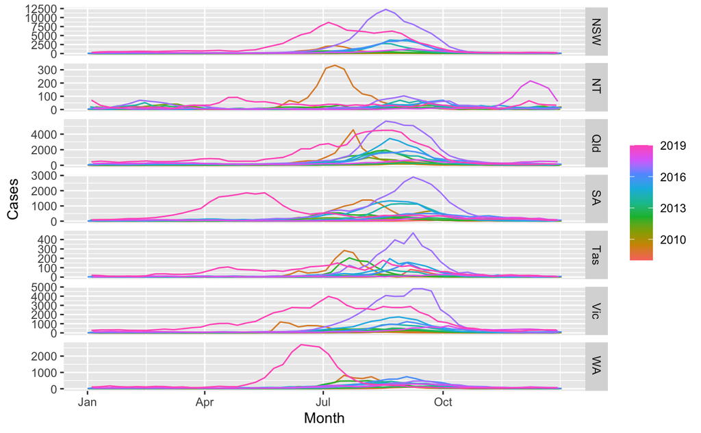

```r
datats %>% group_by(State) %>%
  summarise(Cases = sum(Cases)) %>%
  gg_season() + labs(x = "Month")
```

Fix the periodicity for `tsibble` and decompose into STL elements:

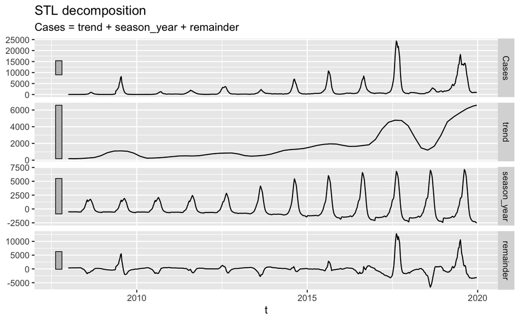

## Hypotheses

**1.**

Adjacent states are more likely to have correlated case patterns

More precisely, the correlation is downstream of cross-border travel volume

**2.**

Flu spread is directly related to the temperature

**3.**

It’s possible to predict the total volume (number of cases in a year) with some accuracy from monitoring the early growth rate

### Hypothesis 1 - interstate correlations

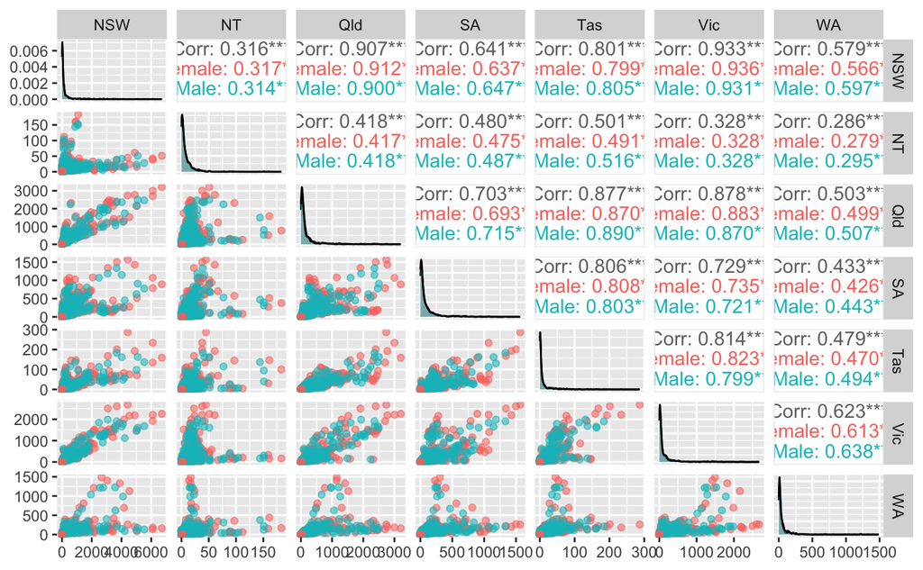

Cross-correlations

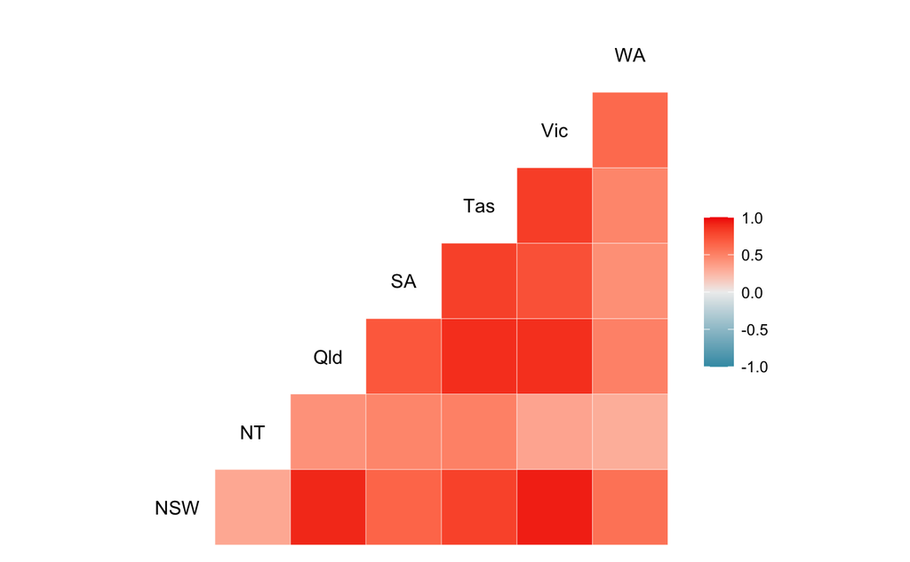

```r
statedatats <- datats %>%
  group_by(State) %>%
  summarise(Cases = sum(Cases)) %>%
  pivot_wider(values_from = Cases, names_from = State, values_fill = 0)
  GGally::ggcorr(statedatats, columns = 2:8)
```

Adjacency matrix:

```r
adjacencies <- matrix(c("NSW","Qld",
         "NSW","Vic",
         "NSW","SA",
         "NT","WA",
         "NT","SA",
         "NT","Qld",
         "Qld","SA",
         "SA","Vic",
         "SA","WA",
         "Tas","Vic"),
       ncol = 2, byrow = TRUE) %>%
  graph_from_edgelist(directed = FALSE)

visIgraph(adjacencies)
```

[interactive chart not shown]

```r
NA
```

```r
statedatats %>% as.data.frame() %>% select(2:8) %>% cor() -> a
adjacencies %>% as_adjacency_matrix() -> b

# need to correct order of matrix b (not alphabetical):
#     NSW Qld Vic SA NT WA Tas
# NSW   .   1   1  1  .  .   .

order_v <- match(colnames(a),colnames(b))
b <- b[order_v,order_v]
b[lower.tri(b)] <- 0

# colnames(a) == colnames(b)

b_inv <- b
b_inv[] <- 0
b_inv[upper.tri(b)&b==0] <- 1

corr_comparison <- rbind(
  tibble(adjacency = "adjacent", correlation = (a*b)[b!=0]),
  tibble(adjacency = "non-adjacent", correlation = (a*b_inv)[b_inv!=0]))
```

```
<sparse>[ <logic> ]: .M.sub.i.logical() maybe inefficient
<sparse>[ <logic> ]: .M.sub.i.logical() maybe inefficient
```

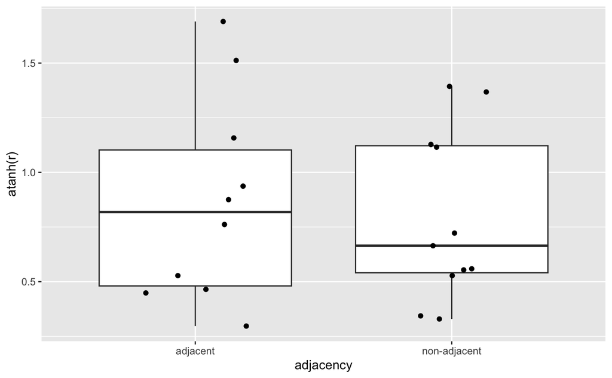

```r
#fisher

corr_comparison$correlation <- corr_comparison$correlation %>% atanh()

corr_comparison %>%
  ggplot(aes(x = adjacency, y = correlation)) +
  geom_boxplot() +
  geom_jitter(alpha = 1, width = .2) + labs(y = "atanh(r)")
```

```r
NA
NA
```

To be robust, would likely need to weight correlations in these comparisons by a relevant metric, like population size (or a pair-wise flow, like travel). Australia Trade and Investment has detailed traveller-per-state [data](https://www.tra.gov.au/data-and-research) but not the pair-wise flows. The ABS has [internal migration flows](https://www.abs.gov.au/statistics/people/population/regional-internal-migration-estimates-provisional/latest-release), but this may be an imperfect proxy for actual trips.

### Hypothesis 2 - temperature

Need weekly temperature data by state.

Most population lives in the major city, so using the weather in the capital.

**Ingest**

For each state, we want to get a vector of the average maximum temperature in the capital each day, and join it with the cases data.

To do this, we get the co-ordinates of each capital and feed it a weather API, which returns a temperature vector of daily maxima.

As our case data is weekly, we then compute a 7-day moving average to use.

```r
library(httr)

# "https://archive-api.open-meteo.com/v1/archive?latitude=-33.87&longitude=151.21&start_date=2008-01-04&end_date=2021-12-31&daily=temperature_2m_max,temperature_2m_min&timezone=Australia%2FSydney"

# get co-ordinates of capitals

locations <- tibble(
  state = c("NSW",    "NT",     "Qld",      "SA",       "Tas",    "Vic",       "WA"),
  city  = c("Sydney", "Darwin", "Brisbane", "Adelaide", "Hobart", "Melbourne", "Perth")
)

get_temps = function(city) {
  coords <- geo(city = city, country = "Australia")

  base_url <- "https://archive-api.open-meteo.com/v1/archive"

  queries <- list(
    latitude = coords$lat,
    longitude = coords$long,
    start_date = min(datats$Week),
    end_date = max(datats$Week),
    daily = "temperature_2m_max",
    timezone = "Australia/Sydney")

  weather_data <- GET(modify_url(base_url, query = queries))

  output <- tibble(
    date = content(weather_data)$daily$time,
    temp = content(weather_data)$daily$temperature_2m_max
  )

  output %>% mutate(
    city = city,
    date = date %>% unlist() %>% as_date(),
    temp = temp %>% unlist()
    )
}

temp_data_list <- map(locations$city, get_temps)
```

```
Passing 1 address to the Nominatim single address geocoder
Query completed in: 1.4 seconds
Passing 1 address to the Nominatim single address geocoder
Query completed in: 1 seconds
Passing 1 address to the Nominatim single address geocoder
Query completed in: 1 seconds
Passing 1 address to the Nominatim single address geocoder
Query completed in: 1 seconds
Passing 1 address to the Nominatim single address geocoder
Query completed in: 1 seconds
Passing 1 address to the Nominatim single address geocoder
Query completed in: 1 seconds
Passing 1 address to the Nominatim single address geocoder
Query completed in: 1 seconds
```

```r
temp_data <- bind_rows(temp_data_list) %>%
  left_join(locations, by = "city") %>%
  mutate(
    avg_temp = slider::slide_dbl(temp, mean,
                .before = 3, .after = 3, .complete = TRUE))

case_data <- data %>%
  filter(Week < as.Date("2020-01-01 UTC")) %>%
  group_by(Week,State) %>%
  summarise(cases = n()) %>%
  transmute(date = as.Date(floor_date(Week, unit = "1 week")), state = State, cases)
combined_data <- left_join(case_data,temp_data) %>%
  ungroup() %>%
  select(date,state,cases,avg_temp) %>%
  as_tsibble(index = date,key = c(state))
combined_data %>% head()
```

| date | state | cases | avg_temp |
| --- | --- | --- | --- |
| 2007-12-30 | NSW | 1 | NA |
| 2008-01-06 | NSW | 4 | NA |
| 2008-01-13 | NSW | 2 | 23.64286 |
| 2008-01-20 | NSW | 5 | 19.04286 |
| 2008-01-27 | NSW | 4 | 22.07143 |
| 2008-02-03 | NSW | 8 | 21.41429 |

```r
NA
```

```r
combined_data
```

[output not shown]

### Hypothesis 3 - early growth rates

Taking just the seasonal component of the ETL model shows a predictable ramp-up:

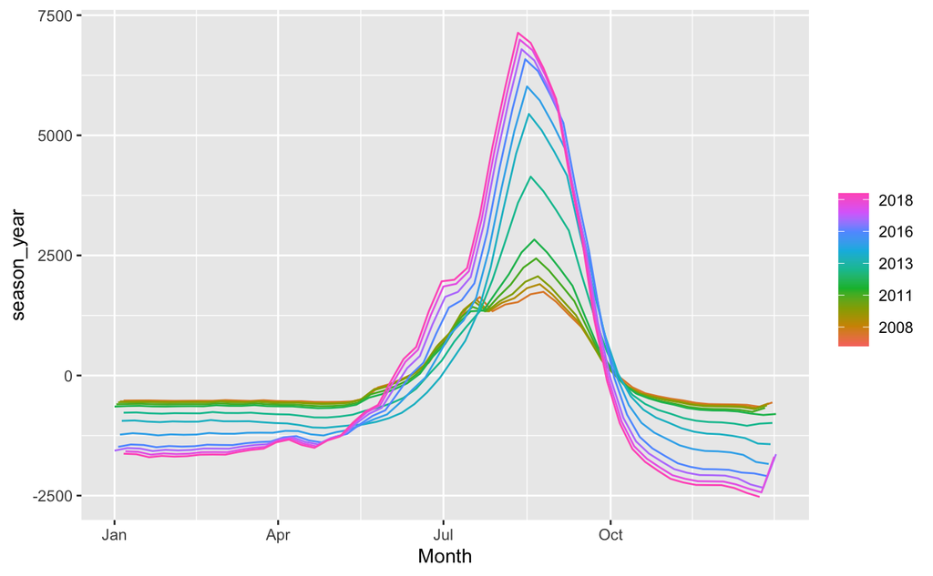

```r
data_for_model %>%
  model(feasts::STL(Cases)) %>%
  components() %>%
  gg_season(y = season_year) + labs(x = "Month")
```

corr by population?

```r
datats %>%
  group_by(State) %>%
  summarise(Cases = sum(Cases)) %>%
  lm(Cases ~ State, data = .)
```

[output not shown]